# Testing truncsm with Simulated Data

```r
library(ggplot2)
library(Rfast)
library(Directional)
library(truncsm)
```

## von-Mises Fisher distribution

We simulate $n=1000$ samples from a von-Mises distribution with mean direction $(\pi/2, \pi)$ on the sphere, using the `rvmf` function from the `Rfast` package.

```r
# Simulated VMF
n = 1000
centre = c(pi/2, pi)
centre_euclid = sphere_to_euclid(centre)
set.seed(4)
z = rvmf(n, centre_euclid, k = 6)
x = euclid_to_sphere(z)
```

Now this can be estimated directly, using various methods such as MLE, but if we could only see a portion of this data, then truncated score matching can be used. Say there is a boundary set up such that all measurements below a constant line of $\phi = \pi/2 + 0.2$ were missing. This can be constructed as follows

```r
dV = cbind(rep(pi/2+0.2, 200), seq(0, 2*pi, len=200))
outside_boundary = x[,1] > (pi/2+0.2)
truncated_x = x[outside_boundary,]
```

The mean direction can be estimated by calling `sphere_sm` with a specified boundary function, one of `"Haversine"` or `"Euclidean"`.

```r
est_hav = sphere_sm(truncated_x, dV, g = "Haversine", family = vmf(k=6))
est_euc = sphere_sm(truncated_x, dV, g = "Euclidean", family = vmf(k=6))
```

Note that the `family` argument is `vmf(k=6)`. This is a wrapper function that specifies which distribution to use. The argument `k=6` corresponds to the concentration parameter being fixed a t 6, if this weren’t supplied and `vmf()` was used alone, the concentration parameter will be esitmated. By default the `sphere_sm` function uses the von Mises Fisher distribution without specifying a value for `k`. Now that the points are estimated, we can plot them using `ggplot`.

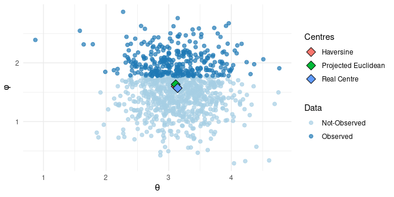

```r
plot_data = data.frame(colat = c(x[!as.logical(outside_boundary),1],
                                 x[as.logical(outside_boundary),1]),
                       lon = c(x[!as.logical(outside_boundary),2],
                               x[as.logical(outside_boundary),2]),
                       Data = c(rep("Not-Observed", sum(!as.logical(outside_boundary))),
                                rep("Observed", sum(outside_boundary))))
centre_data = data.frame(
  colat = c(est_hav$mu[1], est_euc$mu[1], centre[1]),
  lon = c(est_hav$mu[2], est_euc$mu[2], centre[2]),
  Centres = c("Haversine", "Projected Euclidean", "Real Centre")
)
 ggplot(plot_data) + geom_point(aes(x=lon, y=colat, col=Data), alpha=.7, size=2) +
  scale_color_brewer(type="qual", palette=3) + theme_minimal() +
  xlab(expression(theta)) + ylab(expression(phi)) +
   geom_point(data=centre_data, aes(lon, colat, fill=Centres), size=4, shape = "diamond filled")
```

The point has been estimated reasonably well. Now lets try the same approach *without* fixing the concentration parameter.

```r
est_hav = sphere_sm(truncated_x, dV, g = "Haversine", family = vmf())
est_euc = sphere_sm(truncated_x, dV, g = "Euclidean", family = vmf())
```

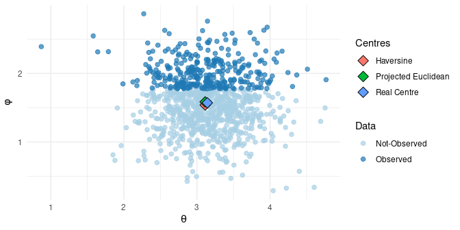

Again, the centre has been found with good accuracy. We can inspect the output of `sphere_sm` to see what value was estimated for `k`.

```r
est_hav
```

```
#> $mu
#>    colat      lon
#> 1.539329 3.112377
#>
#> $k
#>        k
#> 5.415736
#>
#> $family
#> [1] "von Mises Fisher"
#>
#> $val
#> [1] -2.044959
```

```r
est_euc
```

```
#> $mu
#>    colat      lon
#> 1.584297 3.111693
#>
#> $k
#>        k
#> 5.481328
#>
#> $family
#> [1] "von Mises Fisher"
#>
#> $val
#> [1] -1.713839
```

### A different Boundary

We can experiment with a different boundary, implementing the same approach to the same dataset but a different truncation region. Start by simulating different data from the same distribution and constructing the boundary as before:

```r
set.seed(7)
z = rvmf(n, centre_euclid, k = 6)
x = euclid_to_sphere(z)
dV = cbind(c(rep(1.2, 200), seq(1.2, 3, len=200)), c(seq(0, 3.6, len=200), rep(3.6, len=200)))
outside_boundary = x[,2] < 3.6 & x[,1] > 1.2
truncated_x = x[as.logical(outside_boundary),]
```

So in this case, the boundary is anything that fits $\phi > 1.2$ and $\theta < 3.6$, roughly a box around the top left portion of the data. We call `sphere_sm` as before.

```r
est_hav = sphere_sm(truncated_x, dV, g = "Haversine", family=vmf())
est_euc = sphere_sm(truncated_x, dV, g = "Euclidean", family=vmf())
```

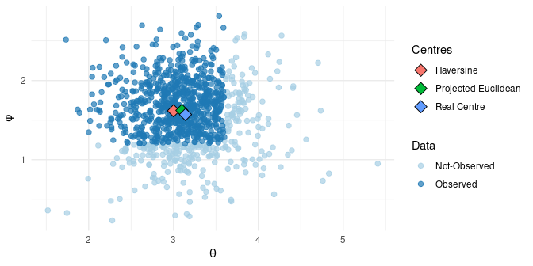

The results are slightly less accurate than before, but still hold.

## Kent Distribution

We adopt a similar approach for the Kent distribution, simulating data, truncating it at an artificial boundary and experimenting with fitting the model to see how well the estimated mean direction $\mu$ is. Firstly, we use a boundary similar to before, truncated at $\phi = \pi/2+0.1$.

```r
z = rkent(n, k = 10, m = centre_euclid, b=3)
x = euclid_to_sphere(z)
dV = cbind(rep(pi/2+0.1, 500), seq(0, 2*pi, len=500))
outside_boundary = x[,1] > (pi/2 + 0.1)
truncated_x = x[outside_boundary,]
```

Since the Kent distribution has five parameters, estimation can be difficult and slow in some cases. For the Kent distribution, we assume that the concentration parameter `k` and ovalness parameter `b` are known, and specified in advance.

```r
est_hav = sphere_sm(truncated_x, dV, g="Haversine", family=kent(k=10, b=3))
est_euc = sphere_sm(truncated_x, dV, g="Euclidean", family=kent(k=10, b=3))
```

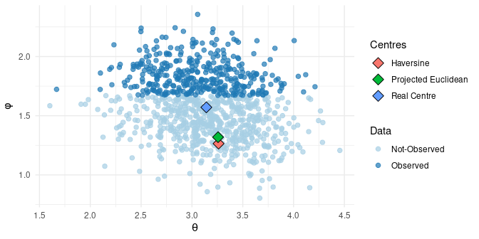

And another boundary, similar to before.

```r
set.seed(12)
z = rkent(n, m=centre_euclid, k = 10, b=3)
dV = cbind(c(rep(1.2, 200), seq(1.2, 3, len=200)), c(seq(0, 3.6, len=200), rep(3.6, len=200)))
x = euclid_to_sphere(z)
outside_boundary = x[,2] < 3.6 & x[,1] > 1.2
truncated_x = x[as.logical(outside_boundary),]

est_hav = sphere_sm(truncated_x, dV, g = "Haversine", family=kent(k=10, b=3))
est_euc = sphere_sm(truncated_x, dV, g = "Euclidean", family=kent(k=10, b=3))
```

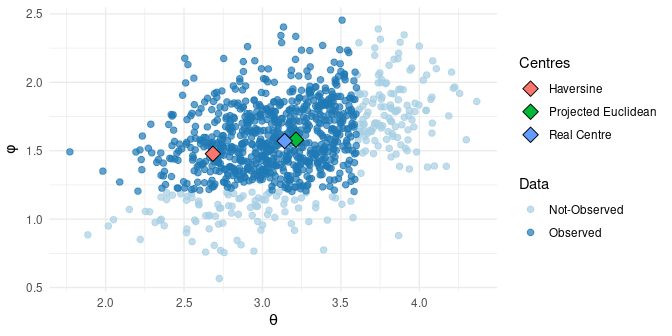